# Importing Necessary Libraries

```python
!pip install tensorflow
!pip install mlxtend
!pip install seaborn
!pip install matplotlib
!pip install -q transformers datasets
!pip install transformers datasets torch scikit-learn
```

```python
import pandas as pd
import seaborn as sns
import matplotlib.pyplot as plt
import tensorflow as tf
import numpy as np

from mlxtend.frequent_patterns import apriori, association_rules
from tensorflow.keras import Sequential
from tensorflow.keras.layers import Conv2D, MaxPooling2D, Flatten, Dense
from tensorflow.keras.utils import to_categorical
from sklearn.model_selection import train_test_split
from tensorflow.keras.optimizers import Adam
from tensorflow.keras.datasets import mnist
```

## 1Q. [Association Rule Generation from Transaction Data]

## 1c.

### • How many unique items are there in your dataset?

### • How many records are there in your dataset?

### • What is the most popular item in your dataset? How many transactions contain this item?

```python
file_path = r"C:\Users\Lokesh Kumar\OneDrive\Documents\DM\Grocery_Items_1.csv"
data = pd.read_csv(file_path)


Items = data.melt(var_name="Transaction", value_name="Item")['Item']
Items = Items.dropna()

# 1. How many unique items are there in your dataset?
unique_items_count = Items.nunique()
print(f"Number of unique items: {unique_items_count}")

# 2. How many records are there in your dataset?
total_records = len(data)
print(f"Number of records: {total_records}")

# 3. What is the most popular item in your dataset? How many transactions contain this item? (1 point)
item_counts = Items.value_counts()
max_count = item_counts.max()
most_popular_items = item_counts[item_counts == max_count].index.tolist()


print(f"Most popular item(s): {most_popular_items} with {max_count} transactions.")
```

```
Number of unique items: 165
Number of records: 8000
Most popular item(s): ['whole milk'] with 1342 transactions.
```

## 1d.

### Using minimum support = 0.01 and minimum confidence threshold = 0.08, what are the association rules you can extract from your dataset?

```python
transactions = data.apply(lambda row: row.dropna().tolist(), axis=1)
transaction_df = pd.DataFrame([{item: 1 for item in row} for row in transactions]).fillna(0).astype(bool)

frequent_itemsets = apriori(transaction_df, min_support=0.01, use_colnames=True)

if frequent_itemsets.empty:
    print("No frequent itemsets found. Try reducing the min_support threshold.")
else:
    rules = association_rules(frequent_itemsets, metric="confidence", min_threshold=0.08, num_itemsets=2)

print("Association Rules with exactly 2 items in antecedents or consequents:")
print(rules)
```

```
Association Rules with exactly 2 items in antecedents or consequents:
          antecedents         consequents  antecedent support  \
0              (soda)        (whole milk)            0.100500
1            (yogurt)        (whole milk)            0.086625
2  (other vegetables)        (whole milk)            0.120375
3        (whole milk)  (other vegetables)            0.157000
4        (rolls/buns)        (whole milk)            0.111000
5        (whole milk)        (rolls/buns)            0.157000
6  (other vegetables)              (soda)            0.120375
7              (soda)  (other vegetables)            0.100500
8        (rolls/buns)  (other vegetables)            0.111000
9  (other vegetables)        (rolls/buns)            0.120375

   consequent support   support  confidence      lift  representativity  \
0            0.157000  0.011625    0.115672  0.736762               1.0
```

[output cut: 21 more lines]

## 1e.

### Use minimum support values (msv): 0.001, 0.005, 0.01 and minimum confidence threshold (mct): 0.05, 0.075, 0.1. For each pair (msv, mct), find the number of association rules extracted from the dataset. Construct a heatmap using Seaborn data visualization library to show the count results such that the x-axis is msv and the y-axis is mct.

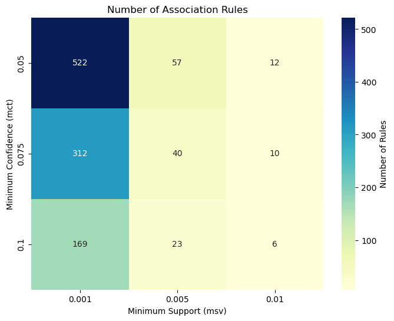

```python
min_support_values = [0.001, 0.005, 0.01]
min_confidence_thresholds = [0.05, 0.075, 0.1]

rule_counts = pd.DataFrame(index=min_confidence_thresholds, columns=min_support_values)

for msv in min_support_values:
    for mct in min_confidence_thresholds:
        frequent_itemsets = apriori(transaction_df, min_support=msv, use_colnames=True)

        if not frequent_itemsets.empty:
            rules = association_rules(frequent_itemsets, metric="confidence", min_threshold=mct, num_itemsets=2)
            rule_counts.loc[mct, msv] = len(rules)
        else:
            rule_counts.loc[mct, msv] = 0

rule_counts = rule_counts.astype(int)


plt.figure(figsize=(8, 6))
sns.heatmap(rule_counts, annot=True, fmt="d", cmap="YlGnBu", cbar_kws={'label': 'Number of Rules'})
plt.title("Number of Association Rules")
plt.xlabel("Minimum Support (msv)")
plt.ylabel("Minimum Confidence (mct)")
plt.show()
```

## 2Q. [Image Classification using CNN]

### a. Plot a graph to show the learning curves (i.e., x-axis: number of epochs; y-axis: training and validation accuracy - 2 curves)

```
310/310 ━━━━━━━━━━━━━━━━━━━━ 4s 8ms/step - accuracy: 0.7908 - loss: 0.6785 - val_accuracy: 0.9748 - val_loss: 0.0823
310/310 ━━━━━━━━━━━━━━━━━━━━ 2s 7ms/step - accuracy: 0.9746 - loss: 0.0818 - val_accuracy: 0.9853 - val_loss: 0.0514
310/310 ━━━━━━━━━━━━━━━━━━━━ 2s 6ms/step - accuracy: 0.9822 - loss: 0.0541 - val_accuracy: 0.9869 - val_loss: 0.0376
310/310 ━━━━━━━━━━━━━━━━━━━━ 2s 7ms/step - accuracy: 0.9856 - loss: 0.0434 - val_accuracy: 0.9897 - val_loss: 0.0319
310/310 ━━━━━━━━━━━━━━━━━━━━ 2s 7ms/step - accuracy: 0.9887 - loss: 0.0329 - val_accuracy: 0.9897 - val_loss: 0.0321
310/310 ━━━━━━━━━━━━━━━━━━━━ 2s 7ms/step - accuracy: 0.9913 - loss: 0.0259 - val_accuracy: 0.9915 - val_loss: 0.0241
310/310 ━━━━━━━━━━━━━━━━━━━━ 2s 7ms/step - accuracy: 0.9915 - loss: 0.0243 - val_accuracy: 0.9935 - val_loss: 0.0197
310/310 ━━━━━━━━━━━━━━━━━━━━ 2s 7ms/step - accuracy: 0.9914 - loss: 0.0232 - val_accuracy: 0.9933 - val_loss: 0.0233
310/310 ━━━━━━━━━━━━━━━━━━━━ 2s 7ms/step - accuracy: 0.9939 - loss: 0.0185 - val_accuracy: 0.9929 - val_loss: 0.0212
310/310 ━━━━━━━━━━━━━━━━━━━━ 2s 8ms/step - accuracy: 0.9952 - loss: 0.0148 - val_accuracy: 0.9927 - val_loss: 0.0208
310/310 ━━━━━━━━━━━━━━━━━━━━ 2s 8ms/step - accuracy: 0.9937 - loss: 0.0193 - val_accuracy: 0.9937 - val_loss: 0.0189
310/310 ━━━━━━━━━━━━━━━━━━━━ 2s 8ms/step - accuracy: 0.9948 - loss: 0.0151 - val_accuracy: 0.9933 - val_loss: 0.0188
310/310 ━━━━━━━━━━━━━━━━━━━━ 2s 7ms/step - accuracy: 0.9956 - loss: 0.0150 - val_accuracy: 0.9956 - val_loss: 0.0146
310/310 ━━━━━━━━━━━━━━━━━━━━ 3s 8ms/step - accuracy: 0.9969 - loss: 0.0105 - val_accuracy: 0.9943 - val_loss: 0.0187
310/310 ━━━━━━━━━━━━━━━━━━━━ 2s 7ms/step - accuracy: 0.9962 - loss: 0.0130 - val_accuracy: 0.9962 - val_loss: 0.0142
310/310 ━━━━━━━━━━━━━━━━━━━━ 2s 7ms/step - accuracy: 0.9958 - loss: 0.0122 - val_accuracy: 0.9960 - val_loss: 0.0149
310/310 ━━━━━━━━━━━━━━━━━━━━ 2s 7ms/step - accuracy: 0.9960 - loss: 0.0111 - val_accuracy: 0.9954 - val_loss: 0.0170
310/310 ━━━━━━━━━━━━━━━━━━━━ 3s 7ms/step - accuracy: 0.9964 - loss: 0.0095 - val_accuracy: 0.9945 - val_loss: 0.0172
310/310 ━━━━━━━━━━━━━━━━━━━━ 2s 7ms/step - accuracy: 0.9975 - loss: 0.0085 - val_accuracy: 0.9941 - val_loss: 0.0179
310/310 ━━━━━━━━━━━━━━━━━━━━ 2s 7ms/step - accuracy: 0.9982 - loss: 0.0071 - val_accuracy: 0.9958 - val_loss: 0.0134
```

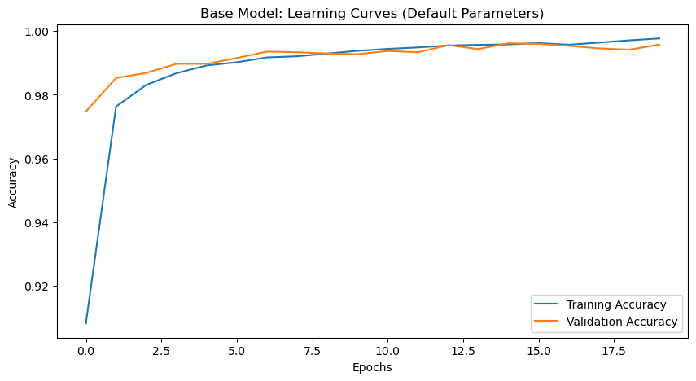

```
Base Model Test Accuracy: 1.00
```

```python
(x_train, y_train), (x_test, y_test) = mnist.load_data()

# Filter dataset to 4 classes (0, 1, 2, 3)
classes_to_use = [0, 1, 2, 3]
x_train = x_train[np.isin(y_train, classes_to_use)]
y_train = y_train[np.isin(y_train, classes_to_use)]
x_test = x_test[np.isin(y_test, classes_to_use)]
y_test = y_test[np.isin(y_test, classes_to_use)]


x_train = x_train / 255.0
x_test = x_test / 255.0
x_train = x_train.reshape(-1, 28, 28, 1)
x_test = x_test.reshape(-1, 28, 28, 1)

y_train = to_categorical(y_train, 4)
y_test = to_categorical(y_test, 4)


def plot_learning_curves(history, title):
    plt.figure(figsize=(10, 5))
    plt.plot(history.history['accuracy'], label='Training Accuracy')
    plt.plot(history.history['val_accuracy'], label='Validation Accuracy')
    plt.xlabel('Epochs')
    plt.ylabel('Accuracy')
    plt.title(title)
    plt.legend()
    plt.show()

# training and plotting base model
base_model = Sequential()
base_model.add(Conv2D(8, (3, 3), activation='relu', input_shape=(28, 28, 1)))
base_model.add(MaxPooling2D(pool_size=(2, 2)))
base_model.add(Conv2D(8, (3, 3), activation='relu'))
base_model.add(MaxPooling2D(pool_size=(2, 2)))
base_model.add(Flatten())
base_model.add(Dense(8, activation='relu'))
base_model.add(Dense(4, activation='softmax'))
base_model.compile(optimizer=Adam(), loss='categorical_crossentropy', metrics=['accuracy'])

history_base = base_model.fit(
    x_train, y_train,
    epochs=20,
    batch_size=64,
    validation_split=0.2,
    verbose=1
)
plot_learning_curves(history_base, "Base Model: Learning Curves (Default Parameters)")

base_test_loss, base_test_accuracy = base_model.evaluate(x_test, y_test, verbose=0)
print(f"Base Model Test Accuracy: {base_test_accuracy:.2f}")
```

```
Training with 8 filters in the 2nd layer
619/619 ━━━━━━━━━━━━━━━━━━━━ 7s 9ms/step - accuracy: 0.8231 - loss: 0.4872 - val_accuracy: 0.9798 - val_loss: 0.0538
619/619 ━━━━━━━━━━━━━━━━━━━━ 4s 6ms/step - accuracy: 0.9827 - loss: 0.0533 - val_accuracy: 0.9889 - val_loss: 0.0326
619/619 ━━━━━━━━━━━━━━━━━━━━ 4s 7ms/step - accuracy: 0.9881 - loss: 0.0349 - val_accuracy: 0.9887 - val_loss: 0.0326
619/619 ━━━━━━━━━━━━━━━━━━━━ 4s 7ms/step - accuracy: 0.9922 - loss: 0.0236 - val_accuracy: 0.9939 - val_loss: 0.0187
619/619 ━━━━━━━━━━━━━━━━━━━━ 5s 6ms/step - accuracy: 0.9931 - loss: 0.0217 - val_accuracy: 0.9939 - val_loss: 0.0183
619/619 ━━━━━━━━━━━━━━━━━━━━ 5s 7ms/step - accuracy: 0.9948 - loss: 0.0161 - val_accuracy: 0.9929 - val_loss: 0.0232
619/619 ━━━━━━━━━━━━━━━━━━━━ 4s 7ms/step - accuracy: 0.9941 - loss: 0.0159 - val_accuracy: 0.9954 - val_loss: 0.0156
619/619 ━━━━━━━━━━━━━━━━━━━━ 4s 7ms/step - accuracy: 0.9948 - loss: 0.0143 - val_accuracy: 0.9954 - val_loss: 0.0142
619/619 ━━━━━━━━━━━━━━━━━━━━ 4s 7ms/step - accuracy: 0.9954 - loss: 0.0132 - val_accuracy: 0.9962 - val_loss: 0.0132
619/619 ━━━━━━━━━━━━━━━━━━━━ 4s 7ms/step - accuracy: 0.9963 - loss: 0.0107 - val_accuracy: 0.9962 - val_loss: 0.0134
619/619 ━━━━━━━━━━━━━━━━━━━━ 4s 7ms/step - accuracy: 0.9963 - loss: 0.0098 - val_accuracy: 0.9954 - val_loss: 0.0155
619/619 ━━━━━━━━━━━━━━━━━━━━ 5s 7ms/step - accuracy: 0.9965 - loss: 0.0091 - val_accuracy: 0.9943 - val_loss: 0.0151
619/619 ━━━━━━━━━━━━━━━━━━━━ 4s 7ms/step - accuracy: 0.9976 - loss: 0.0074 - val_accuracy: 0.9960 - val_loss: 0.0142
619/619 ━━━━━━━━━━━━━━━━━━━━ 4s 7ms/step - accuracy: 0.9978 - loss: 0.0060 - val_accuracy: 0.9964 - val_loss: 0.0101
619/619 ━━━━━━━━━━━━━━━━━━━━ 5s 7ms/step - accuracy: 0.9986 - loss: 0.0049 - val_accuracy: 0.9954 - val_loss: 0.0126
619/619 ━━━━━━━━━━━━━━━━━━━━ 5s 7ms/step - accuracy: 0.9978 - loss: 0.0067 - val_accuracy: 0.9956 - val_loss: 0.0138
619/619 ━━━━━━━━━━━━━━━━━━━━ 4s 6ms/step - accuracy: 0.9984 - loss: 0.0062 - val_accuracy: 0.9968 - val_loss: 0.0104
619/619 ━━━━━━━━━━━━━━━━━━━━ 5s 7ms/step - accuracy: 0.9980 - loss: 0.0054 - val_accuracy: 0.9962 - val_loss: 0.0135
619/619 ━━━━━━━━━━━━━━━━━━━━ 4s 6ms/step - accuracy: 0.9988 - loss: 0.0040 - val_accuracy: 0.9966 - val_loss: 0.0118
619/619 ━━━━━━━━━━━━━━━━━━━━ 3s 5ms/step - accuracy: 0.9992 - loss: 0.0036 - val_accuracy: 0.9964 - val_loss: 0.0116
```

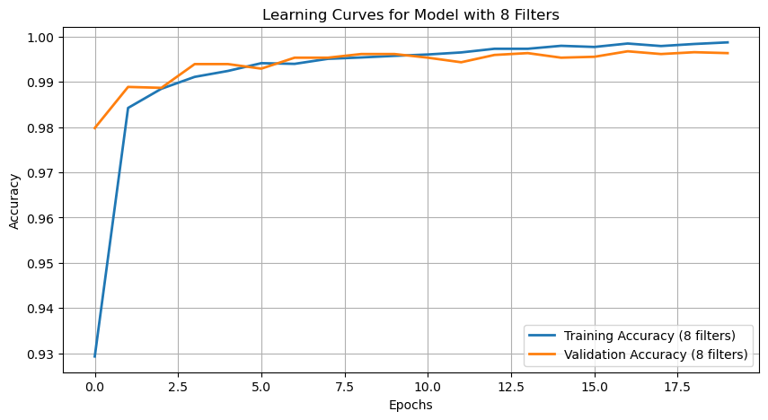

```
Test Accuracy with 8 filters: 1.00

Training with 16 filters in the 2nd layer
619/619 ━━━━━━━━━━━━━━━━━━━━ 6s 6ms/step - accuracy: 0.7734 - loss: 0.5472 - val_accuracy: 0.9818 - val_loss: 0.0585
619/619 ━━━━━━━━━━━━━━━━━━━━ 4s 6ms/step - accuracy: 0.9839 - loss: 0.0548 - val_accuracy: 0.9867 - val_loss: 0.0366
619/619 ━━━━━━━━━━━━━━━━━━━━ 4s 6ms/step - accuracy: 0.9886 - loss: 0.0380 - val_accuracy: 0.9903 - val_loss: 0.0289
619/619 ━━━━━━━━━━━━━━━━━━━━ 4s 6ms/step - accuracy: 0.9903 - loss: 0.0317 - val_accuracy: 0.9909 - val_loss: 0.0253
619/619 ━━━━━━━━━━━━━━━━━━━━ 4s 6ms/step - accuracy: 0.9925 - loss: 0.0245 - val_accuracy: 0.9913 - val_loss: 0.0236
619/619 ━━━━━━━━━━━━━━━━━━━━ 4s 6ms/step - accuracy: 0.9933 - loss: 0.0220 - val_accuracy: 0.9919 - val_loss: 0.0208
619/619 ━━━━━━━━━━━━━━━━━━━━ 5s 6ms/step - accuracy: 0.9953 - loss: 0.0166 - val_accuracy: 0.9952 - val_loss: 0.0155
619/619 ━━━━━━━━━━━━━━━━━━━━ 5s 6ms/step - accuracy: 0.9956 - loss: 0.0137 - val_accuracy: 0.9933 - val_loss: 0.0182
619/619 ━━━━━━━━━━━━━━━━━━━━ 4s 7ms/step - accuracy: 0.9962 - loss: 0.0141 - val_accuracy: 0.9943 - val_loss: 0.0197
619/619 ━━━━━━━━━━━━━━━━━━━━ 5s 8ms/step - accuracy: 0.9972 - loss: 0.0108 - val_accuracy: 0.9943 - val_loss: 0.0160
619/619 ━━━━━━━━━━━━━━━━━━━━ -8s -13564us/step - accuracy: 0.9961 - loss: 0.0107 - val_accuracy: 0.9939 - val_loss: 0.0177
619/619 ━━━━━━━━━━━━━━━━━━━━ 16s 8ms/step - accuracy: 0.9970 - loss: 0.0096 - val_accuracy: 0.9927 - val_loss: 0.0207
619/619 ━━━━━━━━━━━━━━━━━━━━ 4s 7ms/step - accuracy: 0.9972 - loss: 0.0079 - val_accuracy: 0.9941 - val_loss: 0.0189
619/619 ━━━━━━━━━━━━━━━━━━━━ 4s 7ms/step - accuracy: 0.9973 - loss: 0.0081 - val_accuracy: 0.9958 - val_loss: 0.0119
619/619 ━━━━━━━━━━━━━━━━━━━━ 4s 6ms/step - accuracy: 0.9982 - loss: 0.0053 - val_accuracy: 0.9960 - val_loss: 0.0126
619/619 ━━━━━━━━━━━━━━━━━━━━ 4s 6ms/step - accuracy: 0.9985 - loss: 0.0048 - val_accuracy: 0.9958 - val_loss: 0.0143
619/619 ━━━━━━━━━━━━━━━━━━━━ 4s 6ms/step - accuracy: 0.9985 - loss: 0.0047 - val_accuracy: 0.9958 - val_loss: 0.0164
619/619 ━━━━━━━━━━━━━━━━━━━━ 4s 6ms/step - accuracy: 0.9991 - loss: 0.0035 - val_accuracy: 0.9962 - val_loss: 0.0155
619/619 ━━━━━━━━━━━━━━━━━━━━ 4s 6ms/step - accuracy: 0.9975 - loss: 0.0071 - val_accuracy: 0.9966 - val_loss: 0.0131
619/619 ━━━━━━━━━━━━━━━━━━━━ 4s 6ms/step - accuracy: 0.9989 - loss: 0.0039 - val_accuracy: 0.9960 - val_loss: 0.0122
```

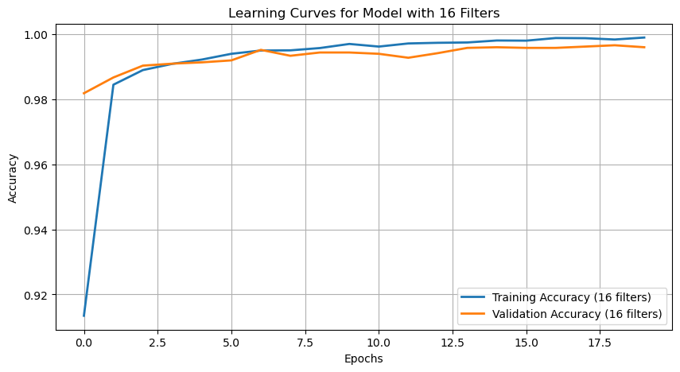

```
Test Accuracy with 16 filters: 1.00
```

```python
def plot_learning_curves(history, num_filters):
    plt.figure(figsize=(10, 5))
    plt.plot(history.history['accuracy'], label=f'Training Accuracy ({num_filters} filters)', linewidth=2)
    plt.plot(history.history['val_accuracy'], label=f'Validation Accuracy ({num_filters} filters)', linewidth=2)
    plt.xlabel('Epochs')
    plt.ylabel('Accuracy')
    plt.title(f'Learning Curves for Model with {num_filters} Filters')
    plt.legend()
    plt.grid(True)
    plt.show()

# Training and plotting for both 8 and 16 filters
filters = [8, 16]
test_accuracies = []

for num_filters in filters:
    print(f"\nTraining with {num_filters} filters in the 2nd layer")
    model = create_model(num_filters)
    history = model.fit(x_train, y_train, validation_split=0.2, epochs=20, batch_size=32, verbose=1)

    plot_learning_curves(history, num_filters)

    test_loss, test_accuracy = model.evaluate(x_test, y_test, verbose=0)
    print(f"Test Accuracy with {num_filters} filters: {test_accuracy:.2f}")
    test_accuracies.append(test_accuracy)
```

## 3Q. [Text Classification by fine-tuning LLM model]

```python
import pandas as pd
```

```python
!pip install transformers datasets torch matplotlib
```

```python
from datasets import load_dataset

# Load dataset
dataset = load_dataset('json', data_files={
    'train': r'C:\Users\Lokesh Kumar\OneDrive\Documents\DM\train.json',
    'validation': r'C:\Users\Lokesh Kumar\OneDrive\Documents\DM\validation.json',
    'test': r'C:\Users\Lokesh Kumar\OneDrive\Documents\DM\test.json'
})
```

```python
dataset
```

```
DatasetDict({
    train: Dataset({
        features: ['ID', 'Tweet', 'anger', 'anticipation', 'disgust', 'fear', 'joy', 'love', 'optimism', 'pessimism', 'sadness', 'surprise', 'trust'],
        num_rows: 3000
    })
    validation: Dataset({
        features: ['ID', 'Tweet', 'anger', 'anticipation', 'disgust', 'fear', 'joy', 'love', 'optimism', 'pessimism', 'sadness', 'surprise', 'trust'],
        num_rows: 400
    })
    test: Dataset({
        features: ['ID', 'Tweet', 'anger', 'anticipation', 'disgust', 'fear', 'joy', 'love', 'optimism', 'pessimism', 'sadness', 'surprise', 'trust'],
        num_rows: 1500
    })
})
```

```python
labels = [label for label in dataset['train'].features.keys() if label not in ['ID', 'Tweet']]
id2label = {idx:label for idx, label in enumerate(labels)}
label2id = {label:idx for idx, label in enumerate(labels)}
labels
```

```
['anger',
 'anticipation',
 'disgust',
 'fear',
 'joy',
 'love',
 'optimism',
 'pessimism',
 'sadness',
 'surprise',
 'trust']
```

```python
from transformers import AutoTokenizer
import numpy as np

tokenizer = AutoTokenizer.from_pretrained("bert-base-uncased")

def preprocess_data(examples):
  # take a batch of texts
  text = examples["Tweet"]
  # encode them
  encoding = tokenizer(text, padding="max_length", truncation=True, max_length=128)
  # add labels
  labels_batch = {k: examples[k] for k in examples.keys() if k in labels}
  # create numpy array of shape (batch_size, num_labels)
  labels_matrix = np.zeros((len(text), len(labels)))
  # fill numpy array
  for idx, label in enumerate(labels):
    labels_matrix[:, idx] = labels_batch[label]

  encoding["labels"] = labels_matrix.tolist()

  return encoding
```

```python
encoded_dataset = dataset.map(preprocess_data, batched=True, remove_columns=dataset['train'].column_names)
```

[output not shown]

```python
example = encoded_dataset['train'][0]
print(example.keys())
```

```
dict_keys(['input_ids', 'token_type_ids', 'attention_mask', 'labels'])
```

```python
tokenizer.decode(example['input_ids'])
```

```
"[CLS] @ daniel _ sankey @ hayleyp79 haha.... actually, after the doggies i ' m barracking for anyone but gws! [SEP] [PAD] [PAD] [PAD] [PAD] [PAD] [PAD] [PAD] [PAD] [PAD] [PAD] [PAD] [PAD] [PAD] [PAD] [PAD] [PAD] [PAD] [PAD] [PAD] [PAD] [PAD] [PAD] [PAD] [PAD] [PAD] [PAD] [PAD] [PAD] [PAD] [PAD] [PA…
```

```python
example['labels']
```

```
[0.0, 0.0, 0.0, 0.0, 1.0, 0.0, 1.0, 0.0, 0.0, 0.0, 0.0]
```

```python
[id2label[idx] for idx, label in enumerate(example['labels']) if label == 1.0]
```

```
['joy', 'optimism']
```

```python
encoded_dataset.set_format("torch")
```

```python
from transformers import AutoModelForSequenceClassification

model = AutoModelForSequenceClassification.from_pretrained("bert-base-uncased",
                                                           problem_type="multi_label_classification",
                                                           num_labels=len(labels),
                                                           id2label=id2label,
                                                           label2id=label2id)
```

```
Some weights of BertForSequenceClassification were not initialized from the model checkpoint at bert-base-uncased and are newly initialized: ['classifier.bias', 'classifier.weight']
You should probably TRAIN this model on a down-stream task to be able to use it for predictions and inference.
```

```python
batch_size = 8
metric_name = "f1"
```

```python
!pip uninstall keras
```

```python
from transformers import TrainingArguments, Trainer

args = TrainingArguments(
    f"bert-finetuned-sem_eval-english",
    evaluation_strategy = "epoch",
    save_strategy = "epoch",
    learning_rate=2e-5,
    per_device_train_batch_size=batch_size,
    per_device_eval_batch_size=batch_size,
    num_train_epochs=5,
    weight_decay=0.01,
    load_best_model_at_end=True,
    metric_for_best_model=metric_name,
    #push_to_hub=True,
)
```

[output not shown]

[output cut: 124 more lines]

[output not shown]

```python
from sklearn.metrics import f1_score, roc_auc_score, accuracy_score
from transformers import EvalPrediction
import torch

# source: https://jesusleal.io/2021/04/21/Longformer-multilabel-classification/
def multi_label_metrics(predictions, labels, threshold=0.5):
    # first, apply sigmoid on predictions which are of shape (batch_size, num_labels)
    sigmoid = torch.nn.Sigmoid()
    probs = sigmoid(torch.Tensor(predictions))
    # next, use threshold to turn them into integer predictions
    y_pred = np.zeros(probs.shape)
    y_pred[np.where(probs >= threshold)] = 1
    # finally, compute metrics
    y_true = labels
    f1_micro_average = f1_score(y_true=y_true, y_pred=y_pred, average='micro')
    roc_auc = roc_auc_score(y_true, y_pred, average = 'micro')
    accuracy = accuracy_score(y_true, y_pred)
    # return as dictionary
    metrics = {'f1': f1_micro_average,
               'roc_auc': roc_auc,
               'accuracy': accuracy}
    return metrics

def compute_metrics(p: EvalPrediction):
    preds = p.predictions[0] if isinstance(p.predictions,
            tuple) else p.predictions
    result = multi_label_metrics(
        predictions=preds,
        labels=p.label_ids)
    return result
```

```python
from transformers import BertTokenizer

# Load BERT tokenizer
tokenizer = BertTokenizer.from_pretrained('bert-base-uncased')

# Tokenizing the dataset
def preprocess_function(examples):
    return tokenizer(examples['Tweet'], padding="max_length", truncation=True)

# Apply the preprocessing function
tokenized_datasets = dataset.map(preprocess_function, batched=True)
```

[output not shown]

```python
tokenized_datasets
```

```
DatasetDict({
    train: Dataset({
        features: ['ID', 'Tweet', 'anger', 'anticipation', 'disgust', 'fear', 'joy', 'love', 'optimism', 'pessimism', 'sadness', 'surprise', 'trust', 'input_ids', 'token_type_ids', 'attention_mask'],
        num_rows: 3000
    })
    validation: Dataset({
        features: ['ID', 'Tweet', 'anger', 'anticipation', 'disgust', 'fear', 'joy', 'love', 'optimism', 'pessimism', 'sadness', 'surprise', 'trust', 'input_ids', 'token_type_ids', 'attention_mask'],
        num_rows: 400
    })
    test: Dataset({
        features: ['ID', 'Tweet', 'anger', 'anticipation', 'disgust', 'fear', 'joy', 'love', 'optimism', 'pessimism', 'sadness', 'surprise', 'trust', 'input_ids', 'token_type_ids', 'attention_mask'],
        num_rows: 1500
    })
})
```